# Lec 11: Missing Data - Solutions

MATH 456 - Spring 2016

```r
lib <- c("VIM", "xtable", "dplyr", "mice", "missForest", "ggplot2","scales", "lattice")
invisible(lapply(lib, library, character.only=T))
```

1. For each distribution listed below, draw a random sample of $n=100$ and delete 20% of the data completely at random and calculate the bias. State if the observed mean over- or under-estimates the true mean.
   1. $X \sim \mathcal{N}(10,2)$
   2. $Y \sim \mathcal{Poisson}(10)$
   3. $B \sim \mathcal{Binomial}(10, .5)$
   4. $F \sim \mathcal{Binomial}(10, .9)$  
      Does the effect of MCAR on the bias differ for the different distributions?
2. Repeat #1 but set the missing data mechanism to b NMAR, where $p$ is negatively correlated with the data.
3. **Using the Parental HIV data set, consider only the following variables: `Age`, `Gender`, `livwith`, `BSI_overall`, `Frnds`, and `Hookey`.**

```r
hiv <- read.delim("C:/GitHub/MATH456/data/PARHIV_022216.txt")
names(hiv) <- tolower(names(hiv))
hiv <- hiv %>% select(age, gender, livwith, bsi_overall, frnds, hookey) %>%
                  mutate(frnds = as.factor(frnds), livwith=as.factor(livwith),
                         hookey = hookey-1)
```

**a. What percent of the data set overall is missing?**

```r
table(is.na(hiv))
```

```
##
## FALSE  TRUE
##  1506     6
```

```r
round(mean(is.na(hiv))*100, 2)
```

```
## [1] 0.4
```

Only 6 pieces of data (0.4%) are missing.

**b. How much missing data is there per variable?**

```r
apply(hiv, 2, function(x) round(sum(is.na(x)),4))
```

```
##         age      gender     livwith bsi_overall       frnds      hookey
##           0           0           0           3           3           0
```

**c. Describe the missing data pattern. (*Hint: Use `aggr` from the `VIM` package for part b and c*)**

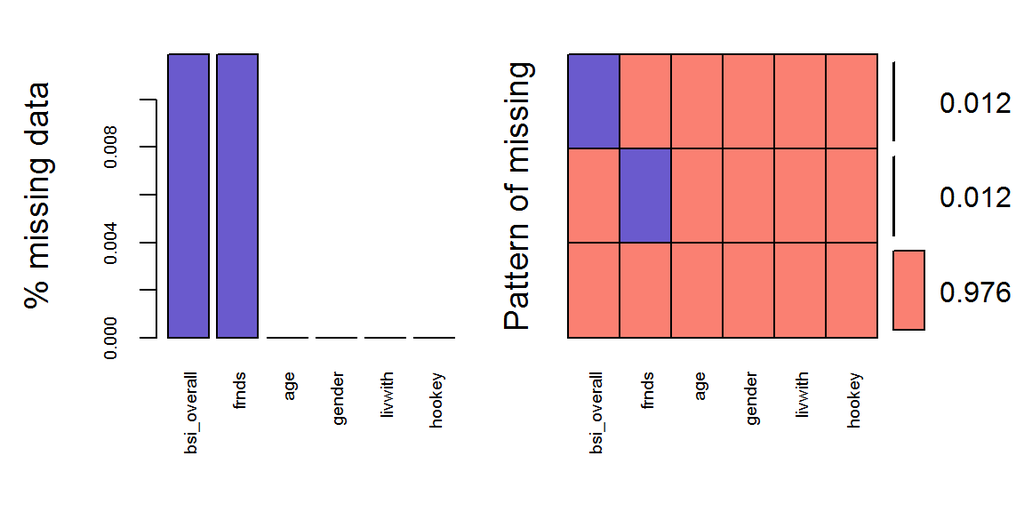

```
##
##  Variables sorted by number of missings:
##     Variable      Count
##  bsi_overall 0.01190476
##        frnds 0.01190476
##          age 0.00000000
##       gender 0.00000000
##      livwith 0.00000000
##       hookey 0.00000000
```

```r
aggr(hiv, col=c("salmon", "slateblue"), numbers=TRUE, sortVars=TRUE, labels=names(hiv),
     cex.axis=.6, gap=3, ylab=c("% missing data", "Pattern of missing"))
```

Only `BSI_overall` and `Frnds` have any missing data, with 3 records each, and they are never missing at the same time.

**d. Describe the relationship of missing data between Age and BSI overall.**

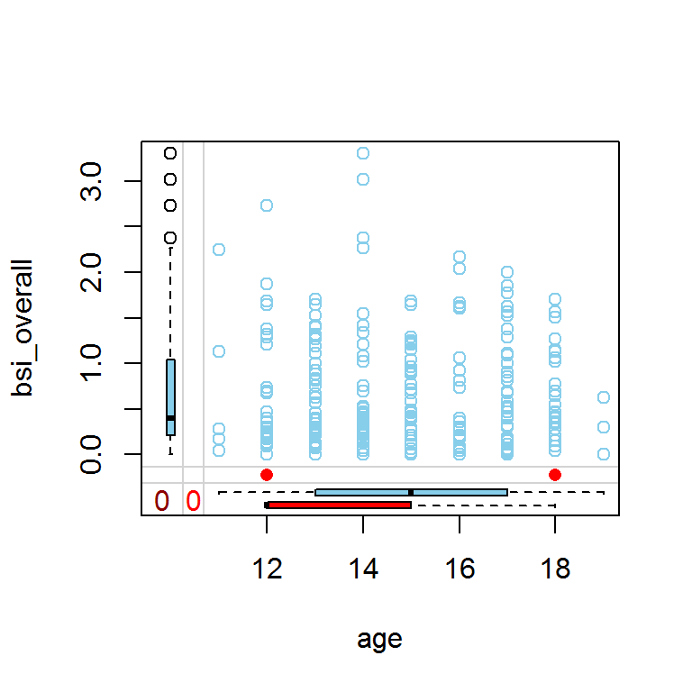

```r
marginplot(hiv[,c(1,4)])
```

It appears that BSI overall is only missing for youth that are either very young (12), or very old (18).

**4. Multiply impute this data set $m=5$ times.**

```r
imp_hiv <- mice(hiv, printFlag=FALSE)
summary(imp_hiv)
```

```
## Multiply imputed data set
## Call:
## mice(data = hiv, printFlag = FALSE)
## Number of multiple imputations:  5
## Missing cells per column:
##         age      gender     livwith bsi_overall       frnds      hookey
##           0           0           0           3           3           0
## Imputation methods:
##         age      gender     livwith bsi_overall       frnds      hookey
##          ""          ""          ""       "pmm"   "polyreg"          ""
## VisitSequence:
## bsi_overall       frnds
##           4           5
## PredictorMatrix:
##             age gender livwith bsi_overall frnds hookey
## age           0      0       0           0     0      0
## gender        0      0       0           0     0      0
## livwith       0      0       0           0     0      0
## bsi_overall   1      1       1           0     1      1
## frnds         1      1       1           1     0      1
## hookey        0      0       0           0     0      0
## Random generator seed value:  NA
```

**a. State the imputation models used for each variable.**

BSI overall was imputed using predictive mean matching, and `frnds` was imputed using polytomous logistic regression. These are the defaults for those variable types.

**5. After controlling for age, who the student lives with, their overall friendships, and overall BSI score, what is the effect of gender on the likelihood a student will skip school? (I.e. Fit a logistic regression model using `hookey` as the outcome and all other covariates as predictors. Calculate the OR and 95% CI for the effect of gender)**

**a. Fit this model on the complete cases (no imputation).**

```r
md_model <- glm(hookey ~ age + gender + livwith + bsi_overall + frnds,
                data=hiv, family="binomial")
print(xtable(summary(md_model), digits=3), type="html")
```

|  | Estimate | Std. Error | z value | Pr(>\|z\|) |
| --- | --- | --- | --- | --- |
| (Intercept) | -9.452 | 1.454 | -6.499 | 0.000 |
| age | 0.686 | 0.102 | 6.744 | 0.000 |
| genderMale | -0.354 | 0.323 | -1.094 | 0.274 |
| livwith2 | -0.364 | 0.416 | -0.876 | 0.381 |
| livwith3 | -0.599 | 0.740 | -0.810 | 0.418 |
| bsi_overall | 0.439 | 0.265 | 1.660 | 0.097 |
| frnds2 | 0.320 | 0.346 | 0.924 | 0.355 |
| frnds3 | 0.013 | 0.499 | 0.026 | 0.979 |
| frnds4 | -1.528 | 0.773 | -1.976 | 0.048 |

```r
exp(c(coef(md_model)[3], confint(md_model)[3,]))
```

```
## genderMale      2.5 %     97.5 %
##  0.7019942  0.3694667  1.3182492
```

Males have 0.70 (.37, 1.32) times the odds of playing hookey compared to females, a non-significant difference (p=.27).

**b. Fit this model on the multiply imputed data sets and pool the results.**

```r
imp_model <- with(imp_hiv, glm(hookey ~ age + gender + livwith + bsi_overall + frnds,
                               data=hiv, family="binomial"))
print(xtable(summary(pool(imp_model))[,c(1:3, 5:7, 9)], digits=3), type="html")
```

|  | est | se | t | Pr(>\|t\|) | lo 95 | hi 95 | fmi |
| --- | --- | --- | --- | --- | --- | --- | --- |
| (Intercept) | -9.452 | 1.454 | -6.499 | 0.000 | -12.317 | -6.586 | 0.008 |
| age | 0.686 | 0.102 | 6.744 | 0.000 | 0.485 | 0.886 | 0.008 |
| genderMale | -0.354 | 0.323 | -1.094 | 0.275 | -0.991 | 0.283 | 0.008 |
| livwith2 | -0.364 | 0.416 | -0.876 | 0.382 | -1.184 | 0.455 | 0.008 |
| livwith3 | -0.599 | 0.740 | -0.810 | 0.419 | -2.057 | 0.859 | 0.008 |
| bsi_overall | 0.439 | 0.265 | 1.660 | 0.098 | -0.082 | 0.961 | 0.008 |
| frnds2 | 0.320 | 0.346 | 0.924 | 0.356 | -0.362 | 1.001 | 0.008 |
| frnds3 | 0.013 | 0.499 | 0.026 | 0.979 | -0.971 | 0.997 | 0.008 |
| frnds4 | -1.528 | 0.773 | -1.976 | 0.049 | -3.051 | -0.004 | 0.008 |

```r
exp(summary(pool(imp_model))[3,c(1,6,7)])
```

```
##       est     lo 95     hi 95
## 0.7019942 0.3712236 1.3274907
```

Males have 0.70 (.37, 1.33) times the odds of playing hookey compared to females, a non-significant difference (p=.27).

**c. Compare these two intervals. Which one is wider? Why?**

The intervals are the same to the second digit.

**d. Discuss the amount of information lost (in terms of sample size and varance) using the complete case method.**

There was no loss of information due to the missing data in this model. The relative small amount of missing data (n=6) did not affect the estimates or standard errors. This is a demonstration of how even if the data was NMAR, the effort required to impute the missing information (even if it wasn’t much effort at all) does not lead to a noticable change in results.

Reiteration of two take home messages / common themes throughout the class.

1. A simpler model is always better
2. When in doubt, do both methods and see if the results actually changed.